# Agglomerative Hierarchical Clustering for Water Chemistry

### 6. Compare Linkage Methods

Use the `dendextend` package to create a tanglegram that compares the dendrograms from complete and single linkage. A tanglegram plot gives two dendrogram, one facing the other, and having their labels connected by lines.

The methods differ in respect to how they define proximity between any two clusters at every step. In single linkage, the proximity between two clusters is determined by the distance between their two closest observations. In contrast, in complete linkage, the proximity between two clusters is measured by the maximum distance between any two points in the clusters.

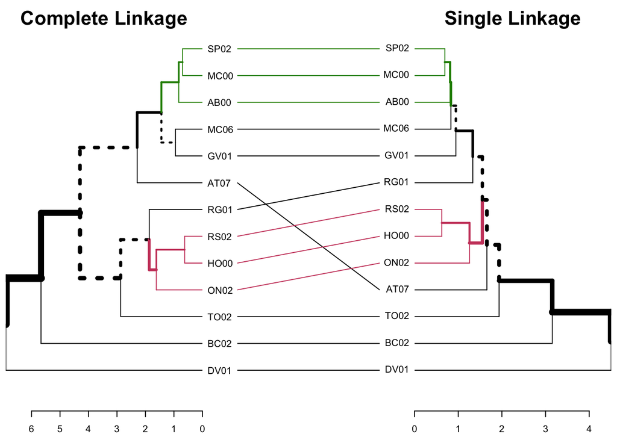

Figure 3: Tanglegram of Two Clustering Method

```r
# plot tanglegram and improve layout with untangle function
untangle(dend_complete, dend_single, method = "step1side") %>%
  tanglegram(
             main_left ="Complete Linkage",
             main_right = "Single Linkage",
             common_subtrees_color_lines = TRUE,
             common_subtrees_color_branches=TRUE,
             highlight_distinct_edges = TRUE,
             lwd = 1)
```

```r
# makes global comparison of two dendrograms trees
all.equal(dend_complete, dend_single)
```

```
[1] "Difference in branch heights -  Mean relative difference: 0.3740403"
```

Prune trees for better visualization

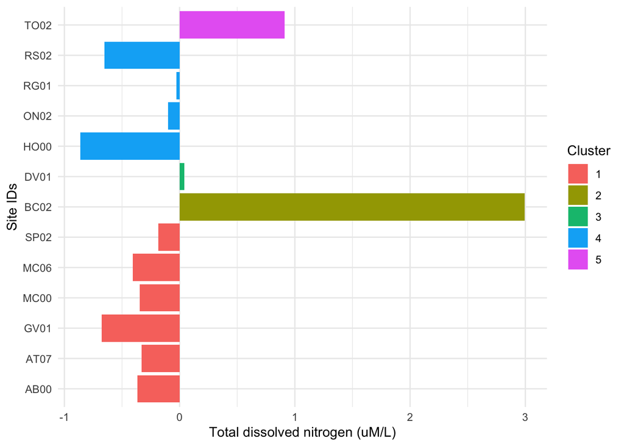

Figure 4: Clustering of Sites by Nitrogen Concentration

```r
# Prepare df for plotting
by_site_scaled <- by_site_scaled %>%
  as.data.frame() %>%
  rownames_to_column(var = "site_code")

# Prune the dendrogram to show only top 5 clusters
hc_cut <- cutree(hc_complete_scaled, k=5)

# Add cluster number to the data
by_site_clustered <- by_site_scaled %>%
  mutate(cluster = hc_cut)

# Plot histogram
ggplot(by_site_clustered, aes(x = reorder(site_code, cluster), y = tdn_uM, fill = factor(cluster)))+
  geom_col()+
  coord_flip()+
  theme_minimal()+
  labs(x="Site IDs", y="Total dissolved nitrogen (uM/L)", fill="Cluster")
```

### Conclusion

The dendrograms from Figure 1 and 2 reveal distinct clusters of sites based on water chemistry. SP02, MC00, and AB00 merge at a low height, indicating highly similar water chemistry, likely due to shared environmental conditions or pollution sources. Similarly, RS02 and HO00 merge at a low height, confirming their high similarity. ON02 clusters with this group, showing significant similarities in water chemistry.

The bar chart in Figure 4 visually represents nitrogen levels across various sites, offering a quantitative measure of water chemistry differences that align with the dendrogram’s clustering patterns. Sites in Cluster 1 (Red) exhibit intermediate nitrogen levels, reflecting their moderate similarity in water chemistry. In contrast, Cluster 2 (Green), which includes only BC02, shows extremely high nitrogen concentrations, explaining its distinct grouping in the dendrogram.